# 🔐 Cybersecurity and Employee Log Analysis at GEAR

This notebook investigates GEAR’s authentication log files and employee data to uncover anomalies, post-employment access attempts, and security policy violations.

## 🔍 Overview of Login Patterns

- Over 1.29 million login attempts were made
- 20% of logins failed, suggesting frequent incorrect authentication attempts
- Most login activity occurs during weekdays, consistent with typical office behavior
- Average login attempts per employee per day: 19–20, reflecting policy of auto-lock and reauthentication

```python
import pandas as pd
import numpy as np
import pandas as pd
from matplotlib import pyplot as plt
```

```python
data = pd.read_csv(r'../data/Cybersecurity_case_study_LoginAnalysis_LogFile.csv', encoding='ISO-8859-1')
```

```python
data.shape
```

```
(1292180, 10)
```

```python
login_counts = data['LoginSuccess'].value_counts()
total = login_counts.sum()
failures = login_counts.get('Failure')
failure_rate = (failures / total)
failure_rate
```

```
np.float64(0.1984514541317773)
```

```python
data['Date'] = pd.to_datetime(data['Date'])
data['DayOfWeek'] = data['Date'].dt.day_name()
login_by_day = data['DayOfWeek'].value_counts()
login_by_day
```

```
DayOfWeek
Tuesday      252117
Wednesday    249695
Friday       240374
Monday       235521
Thursday     232287
Saturday      59952
Sunday        22234
Name: count, dtype: int64
```

```python
weekend_total = login_by_day['Saturday'] + login_by_day['Sunday']
total_logins = login_by_day.sum()
weekend_percentage = weekend_total / total_logins
weekend_percentage
```

```
np.float64(0.06360259406584222)
```

```python
login_counts = data.groupby(['UserName', 'Date']).size()
average_logins = login_counts.mean()
average_logins
```

```
np.float64(19.639486283152216)
```

## 👥 Employee Behavior Analysis

Two datasets were merged: login logs and employee info. This enabled:

### 📊 Per-Employee Summary:

- Total successful and failed logins
- Sorted by activity volume

### ⚠️ Failure Rate Ranking:

```python
data2 = pd.read_csv('../data/Cybersecurity_case_study_LoginAnalysis_EmployeeData.csv', encoding='ISO-8859-1')
```

```python
merged_data = pd.merge(data, data2, on='UserName', how='outer')

merged_data['EndDate'] = pd.to_datetime(merged_data['EndDate'])
```

```python
employee_login = merged_data[(merged_data['UserName'] != 'Admin') & (merged_data['LogEntry'].notna())].copy()

employee_login['SuccessfulLogins'] = (employee_login['LoginSuccess'] == 'Success').astype(int)
employee_login['FailedLogins'] = (employee_login['LoginSuccess'] == 'Failure').astype(int)

login_summary = employee_login.groupby('UserName')[['SuccessfulLogins', 'FailedLogins']].sum().reset_index()

employee_names = employee_login[['UserName', 'FirstName', 'LastName']].drop_duplicates(subset='UserName')

employee_names['EmployeeName'] = employee_names['FirstName'] + ' ' + employee_names['LastName']

login_status_per_employee = pd.merge(employee_names[['UserName', 'EmployeeName']],login_summary,  on='UserName')

login_status_per_employee = login_status_per_employee.sort_values(by='SuccessfulLogins', ascending=False)

login_status_per_employee.head()
```

|  | UserName | EmployeeName | SuccessfulLogins | FailedLogins |
| --- | --- | --- | --- | --- |
| 98 | CGonnin6 | Cullie Gonnin | 10491 | 1074 |
| 347 | NLax62 | Nadeen Lax | 9301 | 985 |
| 206 | GWhitelock12 | Gil Whitelock | 8996 | 2402 |
| 401 | SBenito53 | Son Benito | 8481 | 2235 |
| 187 | GEmons23 | Garrek Emons | 8469 | 3173 |

```python
login_status_per_employee['FailureRate'] = login_status_per_employee['FailedLogins'] / (login_status_per_employee['SuccessfulLogins'] + login_status_per_employee['FailedLogins'])

result_df = login_status_per_employee[['UserName', 'EmployeeName', 'FailureRate']].sort_values(by='FailureRate', ascending=False)

result_df.head()
```

|  | UserName | EmployeeName | FailureRate |
| --- | --- | --- | --- |
| 152 | EJeanneau51 | Evyn Jeanneau | 0.819875 |
| 7 | ABragger43 | Adele Bragger | 0.570687 |
| 281 | LEvennett22 | Leyla Evennett | 0.533605 |
| 338 | MVedeniktov67 | Margery Vedeniktov | 0.474114 |
| 186 | GDunstone64 | Galvin Dunstone | 0.470930 |

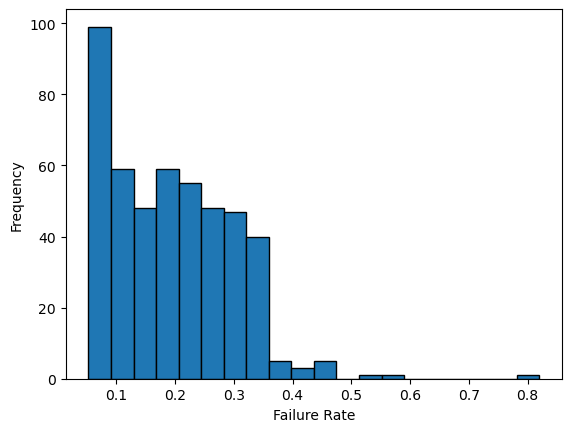

```python
plt.hist(result_df['FailureRate'], bins=20, edgecolor='black')

plt.xlabel('Failure Rate')
plt.ylabel('Frequency')
```

## 🚫 Post-Termination Access Attempts

We identified log entries where employees attempted to log in **after their official end date**.

### Recommendation:

- Implement automated access revocation upon termination
- Perform periodic audit of system permissions

```python
employee_login['EndDate'].notnull().sum()
```

```
np.int64(17973)
```

```python
invalid_logins = employee_login[employee_login['Date'] > (employee_login['EndDate'])].copy()

invalid_logins['EmployeeName'] = invalid_logins['FirstName'] + ' ' + invalid_logins['LastName']

invalid_logins = invalid_logins[['LogEntry', 'EmployeeName', 'EndDate', 'Date', 'LoginSuccess']]

invalid_logins = invalid_logins.sort_values(by='LogEntry', ascending=True)

invalid_logins['EmployeeName'].nunique()
```

```
5
```

```python
invalid_logins_names = invalid_logins['EmployeeName'].unique()

failure_rate_for_invalid_logins = result_df[result_df['EmployeeName'].isin(invalid_logins_names)]

failure_rate_for_invalid_logins[['EmployeeName', 'FailureRate']]
```

|  | EmployeeName | FailureRate |
| --- | --- | --- |
| 267 | Kameko Mathwen | 0.296774 |
| 217 | Hugues MacMenamin | 0.232682 |
| 383 | Richard Giannoni | 0.201629 |
| 38 | Bancroft Aldington | 0.169800 |
| 134 | Dennie Olech | 0.066393 |

```python
invalid_logins[['EmployeeName','EndDate']].drop_duplicates()
```

|  | EmployeeName | EndDate |
| --- | --- | --- |
| 777137 | Kameko Mathwen | 2013-09-14 |
| 401000 | Dennie Olech | 2022-09-28 |
| 122690 | Bancroft Aldington | 2022-10-04 |
| 641377 | Hugues MacMenamin | 2022-11-18 |
| 1065607 | Richard Giannoni | 2022-11-22 |

```python
invalid_logins[['EmployeeName','EndDate','Date']].drop_duplicates()
```

|  | EmployeeName | EndDate | Date |
| --- | --- | --- | --- |
| 777137 | Kameko Mathwen | 2013-09-14 | 2022-05-02 |
| 777161 | Kameko Mathwen | 2013-09-14 | 2022-05-03 |
| 777173 | Kameko Mathwen | 2013-09-14 | 2022-05-04 |
| 777213 | Kameko Mathwen | 2013-09-14 | 2022-05-05 |
| 777251 | Kameko Mathwen | 2013-09-14 | 2022-05-06 |
| ... | ... | ... | ... |
| 641597 | Hugues MacMenamin | 2022-11-18 | 2022-11-29 |
| 401435 | Dennie Olech | 2022-09-28 | 2022-11-30 |
| 1065700 | Richard Giannoni | 2022-11-22 | 2022-11-30 |
| 780388 | Kameko Mathwen | 2013-09-14 | 2022-11-30 |
| 641617 | Hugues MacMenamin | 2022-11-18 | 2022-11-30 |

226 rows × 3 columns

## 🌐 Unauthorized External Logins

### Possible causes:

- Former employees using still-active credentials
- Credential leaks / brute-force attempts

### Recommendations:

- Block login attempts from foreign IPs
- Enforce multi-factor authentication
- Implement geofencing for sensitive systems

```python
df_9 = merged_data[merged_data['FirstName'].isnull()]

df_9.shape
```

```
(1277, 15)
```

```python
df_9['LoginSuccess'].value_counts()
```

```
LoginSuccess
Failure    1277
Name: count, dtype: int64
```

```python
df_9['Country'].value_counts()
```

```
Country
China                  220
Canada                 168
Germany                159
United Kingdom          96
Taiwan                  63
Australia               56
Hong Kong S.A.R.        55
South Korea             51
Netherlands             42
Italy                   40
India                   39
Japan                   32
Belgium                 31
Colombia                21
Switzerland             20
Israel                  18
Mexico                  17
Spain                   16
Turkey                  13
Thailand                13
Sweden                  10
New Zealand              9
France                   9
Austria                  8
Finland                  6
Russia                   6
Trinidad and Tobago      5
Malaysia                 5
Greece                   5
Brazil                   5
Kenya                    5
Norway                   5
Uruguay                  4
Ireland                  4
Bahamas                  4
Guatemala                4
Costa Rica               4
Czechia                  4
Chile                    2
Vietnam                  1
Denmark                  1
Philippines              1
Name: count, dtype: int64
```

```python
df_9['UserName'].unique()
```

```
array(['Admin'], dtype=object)
```

## ✅ Summary

This analysis helps GEAR identify vulnerabilities in its access control framework and enhances organizational readiness against internal and external cybersecurity threats.